# 第3回 ミクロ/マクロ②：賃金・貯蓄と統計の基本

経済データ入門

第3回

ミクロ/マクロ②：賃金・貯蓄と  
統計の基本

平均だけでは語れない。散らばりと形まで見て、はじめて語れる

経済データ入門

第3回 — Topic01

平均と中央値

その「平均」は、何の平均か

## この回の道のり

1

平均と中央値

演習 3-1

106 万円とカード

2

散らばり

演習 3-2

80 点を 100 点に

3

ヒストグラム

演習 3-3

29 で止める

4

形と代表値

演習 3-4

3 文で語る

いまここ — その「平均」は、何の平均か

## 前回の振り返り

前回のポイント — 第2回「企業財務比率」

Q: 会社どうしを比べるとき、何をしたか

- **出どころ**：有価証券報告書の配布 PDF から、連結と単位を確かめて写した
- **比率**：利益や資産を、売上や元手で割ってそろえた
- **データカード**：数字の身元を 7 項目で書いた

今日は「平均」が何の平均かを、並べて数えて確かめる

## 「代表値と散らばり」シートで作る所

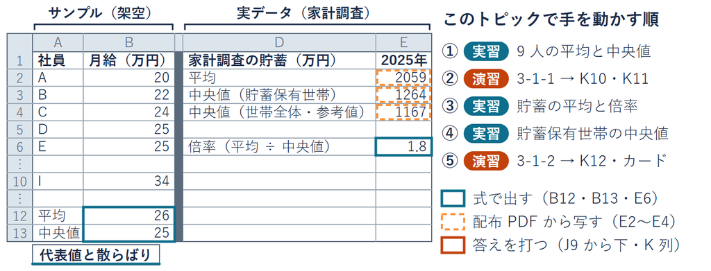

置き場は演習ブック lec3-exercise.xlsx の  
「代表値と散らばり」シート

## 平均月給 26 万円の会社

求人票に「平均月給 26 万円」。入社したら、月給はだいたい 26 万円か

| 社員 | A | B | C | D | E | F | G | H | I |
| --- | --- | --- | --- | --- | --- | --- | --- | --- | --- |
| 月給（万円） | 20 | 22 | 24 | 25 | 25 | 26 | 28 | 30 | 34 |

- **サンプルデータ**：架空の 9 人
- **置き場**：lec3-exercise.xlsx の「代表値と散らばり」シートの 2〜10 行目
- **並び**：小さい順に並べてある（20・22・24・25・25・26・28・30・34）

## 9 人の月給の真ん中と平均

[figure not shown]

真ん中の人は 25 万円。全員で等しく分けると 26 万円

## 平均と中央値の定義

定義

**平均**＝全員の値の合計 ÷ 人数

**中央値**＝小さい順に並べて、ちょうど真ん中の値

- **今回の平均**：234 ÷ 9 ＝ 26（万円）
- **今回の中央値**：9 人なので 5 番目の 25 万円
- **人数が偶数なら**：真ん中の 2 人の平均を、中央値にする

平均は全員の値を使う。中央値は並べた順番で決まる

## 9 人の平均と中央値

STEP 1**平均**：B12 に  
`=AVERAGE(B2:B10)`

STEP 2**中央値**：B13 に  
`=MEDIAN(B2:B10)`

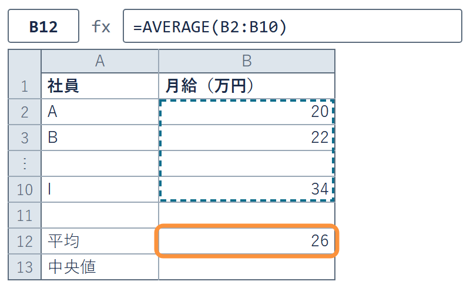

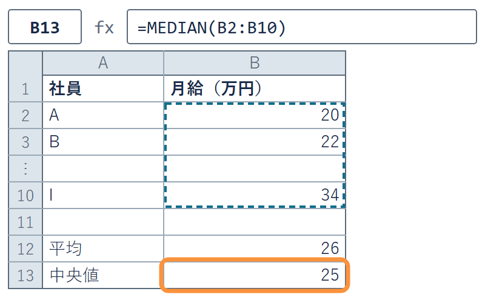

範囲は 9 人の B2:B10。12・13 行目は範囲に入れない

✋ 動画を止めて STEP 1・2 を進め、B12 が 26・B13 が 25 なら再生に戻る

## 演習 3-1-1 1 人の月給の跳ね上がり

演習 3-1-1

I さんの月給だけが 106 万円になると、平均と中央値はいくつか

1. **変える場所**：B10 の 34 を 106 にする（I さんだけ）
2. **考える問い**：B12・B13 はいくつになるか。先に予想してから打つ
3. **答えを打つ**：K10 に B12、K11 に B13 の値を打つ
4. **終わりの条件**：K10・K11 に打ったら、B10 を 34 に戻す

✋ 動画を止めて 2 分。K10・K11 に打ち、B10 を戻したら再生に戻る

## 演習 3-1-1 の答え

演習 3-1-1 の答え

B12 は 34・B13 は 25（平均だけが動く）

- **合計**：234 から 306 へ、72 増える
- **平均**：306 ÷ 9 ＝ 34。8 万円上がる
- **中央値**：106 は 9 番目のまま。5 番目は 25 で変わらない
- **外れ値**：106 のように、ほかから大きく離れた値
- **答え欄**：K10 に 34、K11 に 25 と打てていれば正解

平均は 1 人の大きな値に引っ張られる。中央値は動かない

## 家計調査の貯蓄の平均と中央値

出典：総務省統計局「家計調査年報（貯蓄・負債編）2025年平均」  
配布 PDF の 2 ページ目（本文の頁 1）の表Ⅰ-1-1

| 2025 年・二人以上の世帯 | 万円 |
| --- | --- |
| 貯蓄現在高（平均値・※1） | 2,059 |
| 中央値（貯蓄 0 の世帯も入れた真ん中） | 1,167 |
| 平均 ÷ 中央値 | 2,059 ÷ 1,167 → **約 1.8 倍** |

- **貯蓄現在高**：預貯金・生命保険・有価証券などの、世帯ごとの残高
- **1,167 の場所**：表の右端の列、1,264 の下のカッコ内（注は※3）
- **配布 PDF**：lecture03_家計調査_貯蓄負債編_2025年平均.pdf

## 貯蓄の平均と中央値の倍率

1. **開く**：配布 PDF の 2 ページ目  
   表Ⅰ-1-1 の 2025 年の行
2. **写す**：E2 に 2059、E4 に 1167  
   カンマは打たない
3. **割る**：E6 に `=E2/E4`
4. **そろえる**：E6 を選び `Ctrl + 1`  
   分類「数値」・桁数 1

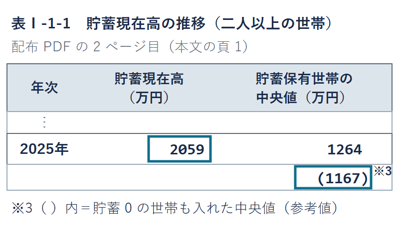

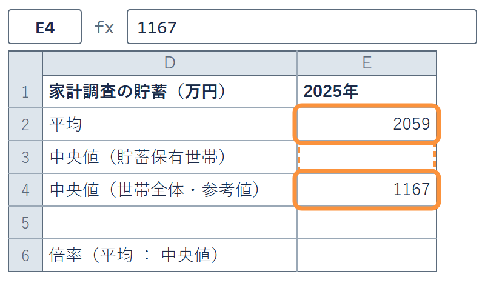

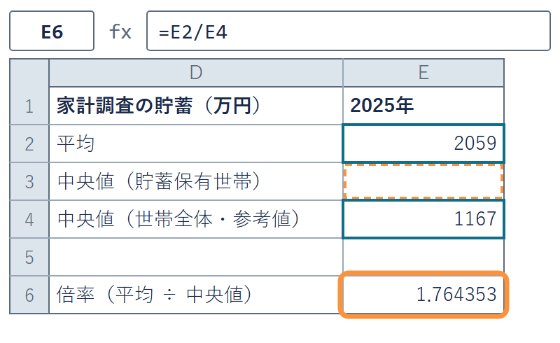

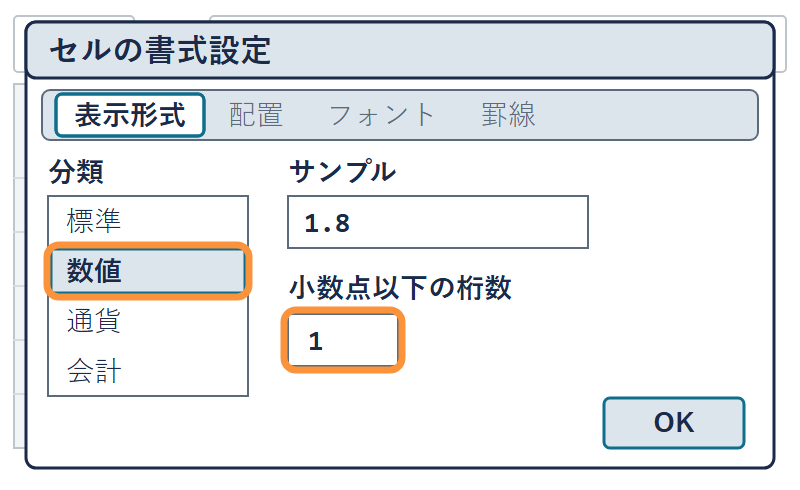

E6 は最初 1.764353。小数 1 桁で 1.8。Mac は `⌘ + 1`

✋ 動画を止めて STEP 1〜4 を進め、E6 が 1.8 なら再生に戻る

## 7 世帯の貯蓄の 2 つの真ん中

[figure not shown]

- **サンプルデータ**：架空の 7 世帯。シートには入れない

貯蓄 0 の世帯を外すと、真ん中が右へずれる

## 世帯全体と貯蓄保有世帯

用語

**世帯全体の中央値**＝貯蓄 0 の世帯も入れて並べた真ん中

**貯蓄保有世帯の中央値**＝貯蓄 0 の世帯を外して並べた真ん中

- **7 世帯の例**：世帯全体なら 700、貯蓄保有世帯なら 1,000
- **配布 PDF の定義**：「0」の世帯を除いて少ない方から並べた、  
  ちょうど中央の世帯（2 ページ目の※2）
- **平均のほう**：平均 2,059 は、  
  貯蓄 0 の世帯も入れた平均（同じページの※1）

「貯蓄の中央値」と書くときは、どちらの中央値かを添える

## 家計調査の 2 つの中央値

同じ配布 PDF の 2 ページ目、表Ⅰ-1-1 の 2025 年の行

| 2025 年・二人以上の世帯 | 万円 |
| --- | --- |
| 中央値（貯蓄保有世帯）＝右端の列 | 1,264 |
| 中央値（世帯全体・参考値）＝その下のカッコ内（※3） | 1,167 |

- **差は 97 万円**：貯蓄 0 の世帯を外すと、  
  真ん中が右へずれる（7 世帯と同じ向き）
- **PDF の本文が示すのは**：1,264 のほう。世帯全体は参考値
- **平均と比べるなら**：平均 2,059 と同じく貯蓄 0 の世帯も入れた 1,167

## 貯蓄保有世帯の中央値

1. **見る**：同じ表の 2025 年の行  
   カッコの外の 1264
2. **写す**：E3 に 1264  
   E2〜E4 の 3 行がそろう

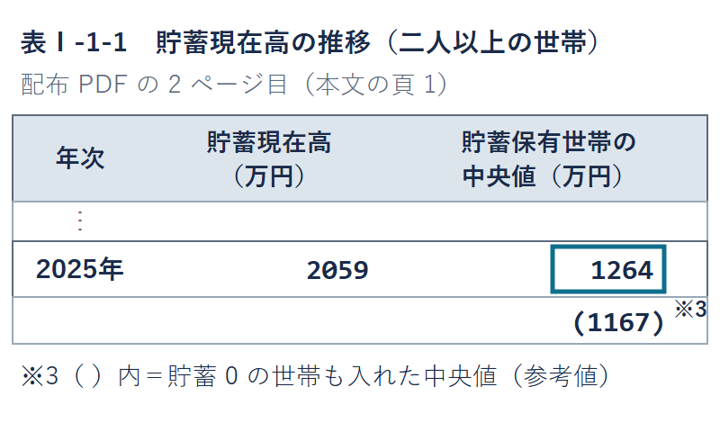

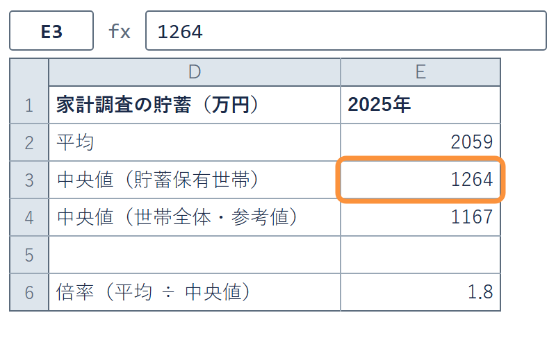

E3 は貯蓄 0 の世帯を外した中央値、E4 は入れた中央値

✋ 動画を止めて STEP 1・2 を進め、E3 が 1264 なら再生に戻る

## 演習 3-1-2 倍率の出し直しとデータカード

演習 3-1-2

貯蓄保有世帯の中央値で割ると何倍か。データカードも埋める

1. **変える場所**：E6 の式の E4 を E3 にする（`=E2/E3`）
2. **考える問い**：1.8 より大きいか小さいか。先に予想してから打つ
3. **答えを打つ**：小数 1 桁の値を K12 に打ち、E6 を `=E2/E4` に戻す
4. **カード**：K17〜K23 の 7 項目を、配布 PDF を見て埋める  
   （出典 4 点セット＝機関・統計名・表の場所・取得日）

✋ 動画を止めて 6 分。K12 とカードを埋めたら再生に戻る

## 演習 3-1-2 の答え

演習 3-1-2 の答え

K12 は 1.6（2,059 ÷ 1,264 → 1.628956）

- **分母が大きくなった**：1,167 から 1,264 へ。  
  だから倍率は 1.8 から 1.6 へ下がる
- **同じ平均でも**：どちらの中央値で割ったかで、倍率が変わる
- **答え欄**：K12 に 1.6、E6 は `=E2/E4` の 1.8 に戻っていれば正解

倍率を書くときも、どちらの中央値で割ったかを添える

## 家計調査のデータカード

| 項目 | 家計調査（貯蓄・負債編）の例 |
| --- | --- |
| 統計名・表番号 | 家計調査年報（貯蓄・負債編）2025年平均 — **表Ⅰ-1-1** |
| 作成機関 | 総務省統計局 |
| 調査の種類 | **標本調査**（選んだ世帯に聞く）・二人以上の世帯・毎年 |
| 単位・基準 | 万円・1 世帯あたり・2025 年平均 |
| 定義の落とし穴 | **中央値が 2 つ**（貯蓄保有世帯 1,264・世帯全体 1,167） ほかに**自分で気づいたこと**を 1 つ |
| 入手先・取得日 | 総務省統計局のサイト（または配布 PDF）・**自分が開いた日** |
| 出典 4 点セット | 総務省統計局 「家計調査年報（貯蓄・負債編）2025年（令和7年）平均」 表Ⅰ-1-1（配布 PDF の 2 ページ目）、開いた日に取得 |

欄は第1回・第2回と同じ 7 つ

## まとめ

- **平均**：合計 ÷ 人数。1 人の外れ値に引っ張られる
- **中央値**：小さい順に並べた真ん中。外れ値では動かない
- **貯蓄の平均**：2,059 万円は、世帯全体の中央値 1,167 万円の約 1.8 倍
- **中央値は 2 つ**：貯蓄保有世帯 1,264・世帯全体 1,167。どちらかを添える
- **出どころ**：配布 PDF の表Ⅰ-1-1 と、データカード 7 項目

次は、平均が同じでも中身がちがう 2 つのクラスを比べる

経済データ入門

第3回 — Topic02

散らばりと標準偏差

平均が同じなら、同じデータか

## この回の道のり

1

平均と中央値

演習 3-1

106 万円とカード

2

散らばり

演習 3-2

80 点を 100 点に

3

ヒストグラム

演習 3-3

29 で止める

4

形と代表値

演習 3-4

3 文で語る

いまここ — 平均が同じなら、同じデータか

## 「代表値と散らばり」シートで作る所

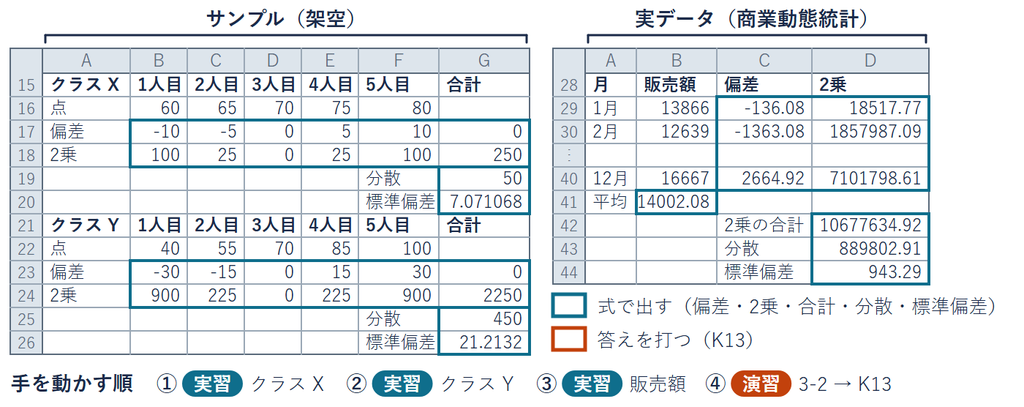

置き場は演習ブック lec3-exercise.xlsx の  
同じシートの 15〜44 行目

## 平均 70 点の 2 クラス

小テストの平均は、どちらのクラスも 70 点。2 つは同じようなクラスか

| 生徒 | 1 人目 | 2 人目 | 3 人目 | 4 人目 | 5 人目 |
| --- | --- | --- | --- | --- | --- |
| クラス X（点） | 60 | 65 | 70 | 75 | 80 |
| クラス Y（点） | 40 | 55 | 70 | 85 | 100 |

- **サンプルデータ**：架空の 2 クラス、5 人ずつ（教科書 8.3）
- **置き場**：lec3-exercise.xlsx の 16 行目と 22 行目
- **代表値**：平均も中央値も、どちらのクラスも 70 点

## 2 クラスの点の並び

[figure not shown]

平均も中央値も同じ 70 点。でも Y の点は広く散らばる

## クラス X の平均からの離れ

[figure not shown]

- **偏差**：点 − 平均。X は −10・−5・0・+5・+10

偏差をそのまま足すと、プラスとマイナスが消えて 0

## 偏差の 2 乗の平均とルート

[figure not shown]

X の点は、平均 70 点からふつう約 7 点離れている

## 偏差・分散・標準偏差の定義

定義

**偏差**＝値 − 平均

**分散**＝偏差の 2 乗の合計 ÷ 人数

**標準偏差**＝分散のルート（√）

| STEP | やること | 今回のクラス X |
| --- | --- | --- |
| 1 | 偏差を出す（値 − 平均） | −10・−5・0・+5・+10 |
| 2 | 偏差を 2 乗する | 100・25・0・25・100 |
| 3 | 2 乗の合計 ÷ 人数（分散） | 250 ÷ 5 ＝ 50（手元の人数 5 で割る） |
| 4 | 分散のルートをとる（標準偏差） | √50 ≒ 7.07（単位が点に戻る） |

標準偏差＝平均から、ふつうどれだけ離れているか

## クラス Y の標準偏差

| 4 歩 | クラス X | クラス Y |
| --- | --- | --- |
| 偏差 | −10・−5・0・+5・+10 | −30・−15・0・+15・+30 |
| 2 乗の合計 | 250 | 2,250 |
| 分散 | 250 ÷ 5 ＝ 50 | 2,250 ÷ 5 ＝ 450 |
| 標準偏差 | √50 ≒ 7.07 | √450 ≒ 21.21 |

- **Y の偏差**：X の偏差の、ちょうど 3 倍
- **だから**：標準偏差も 7.07 のちょうど 3 倍で 21.21

平均が同じでも、Y の散らばりは X のちょうど 3 倍

## 失敗例 平均だけの比較

よくある読み違い

「平均が同じなら  
だいたい同じデータ」  
平均は全員の点を使うので  
それで足りると思いやすい

反例

X は 60〜80 点  
Y は 40〜100 点  
標準偏差は 7.07 と 21.21  
ちょうど 3 倍ちがう

平均と標準偏差を並べて書く（X は 70 点・7.07 点）

## クラス X の偏差と 2 乗

1. **偏差**：B17 に `=B16-70`  
   F17 まで右へ引く  
   （70 は平均。番地で書くと  
   右へ引いたときずれるので数で）
2. **2 乗**：B18 に `=B17*B17`  
   F18 まで右へ引く
3. **合計**：G17 に `=SUM(B17:F17)`  
   G18 まで下へ（番地も 1 行下へ）

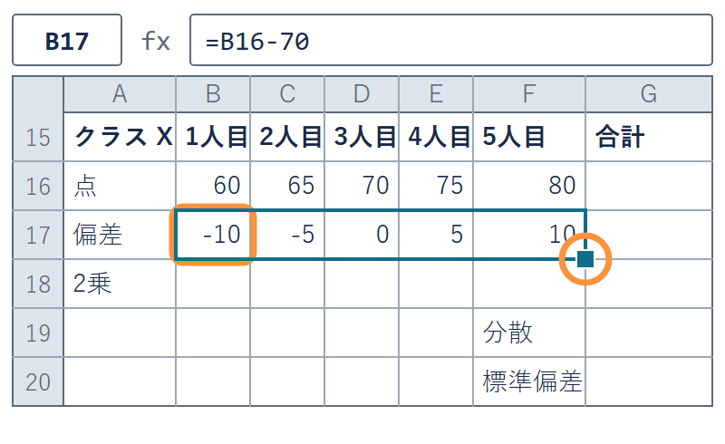

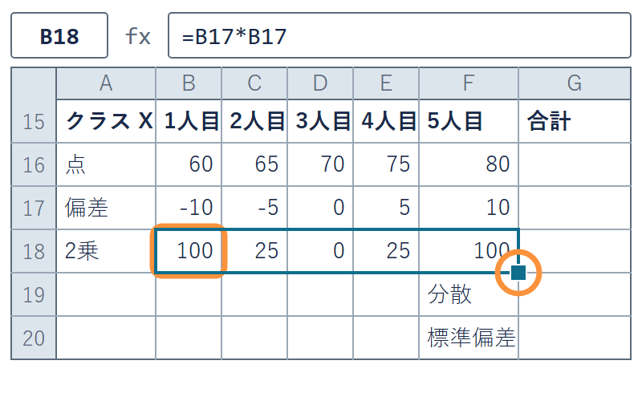

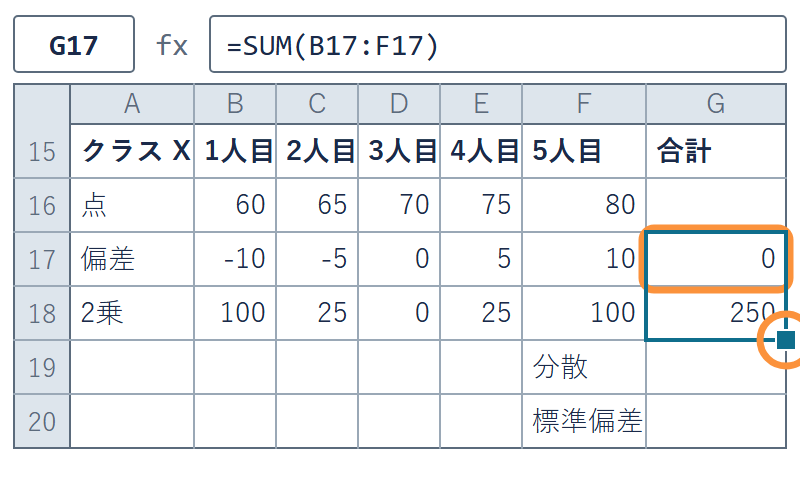

よい書き方ではない。ずれない書き方（絶対参照）は次の回で

✋ 動画を止めて進め、G17 が 0・G18 が 250 なら再生に戻る

## クラス X の分散と標準偏差

1. **分散**：G19 に  
   `=AVERAGE(B18:F18)`  
   2 乗の平均（250 ÷ 5）
2. **標準偏差**：G20 に  
   `=G19^(1/2)`

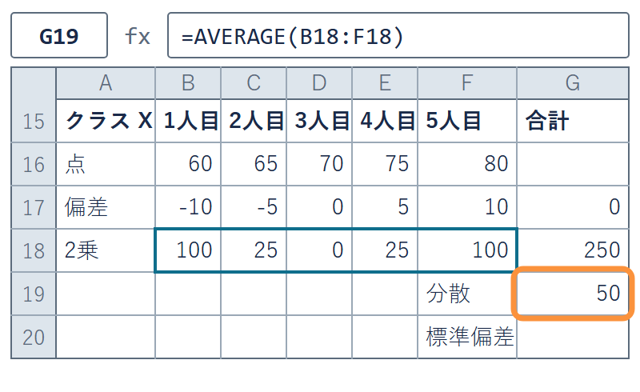

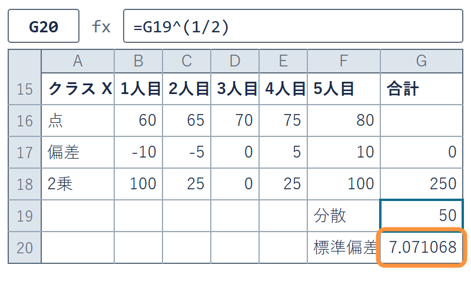

`^` は「〜乗」の記号（0 の 2 つ右のキー）。1/2 乗はルートと同じ

✋ 動画を止めて進め、G20 が 7.07 で始まる数なら再生に戻る

## クラス Y へのコピー

1. **コピー**：B17:G20 を選び  
   `Ctrl + C`
2. **貼る**：B23 に貼る  
   `Ctrl + V`（Mac は ⌘）

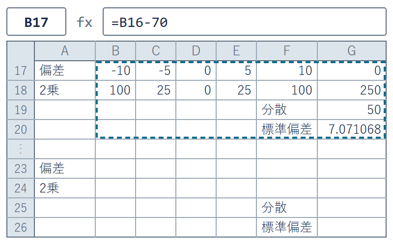

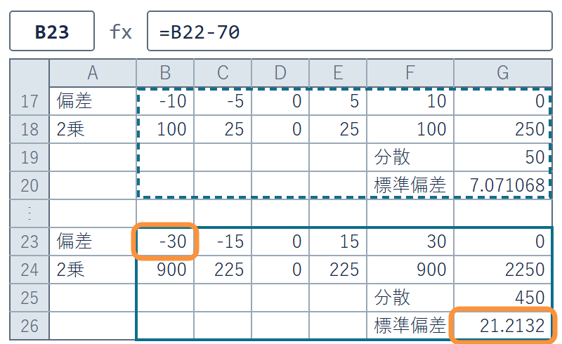

Y の平均も 70 なので、X の式がそのまま使える

✋ 動画を止めて進め、G26 が 21.21 で始まる数なら再生に戻る

## スーパー販売額の 12 か月

今度は、月ごとの販売額の散らばりを見る

[figure not shown]

- **出典**：経済産業省「商業動態統計調査」スーパー販売額 2025 年（億円）
- **置き場**：lec3-exercise.xlsx の 29〜40 行目（第1回の 12 か月）
- **いちばん遠い月**：12 月の 16,667 億円。偏差は +2,664.92

## 販売額の標準偏差

STEP 1**平均**：B41 に  
`=AVERAGE(B29:B40)`

STEP 2**偏差**：C29 に `=B29-14002.08`  
（70 と同じ理由で数で）C40 まで下へ

STEP 3**2 乗**：D29 に `=C29*C29`  
D40 まで下へ引く

STEP 4**仕上げ**：D42 に `=SUM(D29:D40)`

D43 に `=AVERAGE(D29:D40)`

D44 に `=D43^(1/2)`

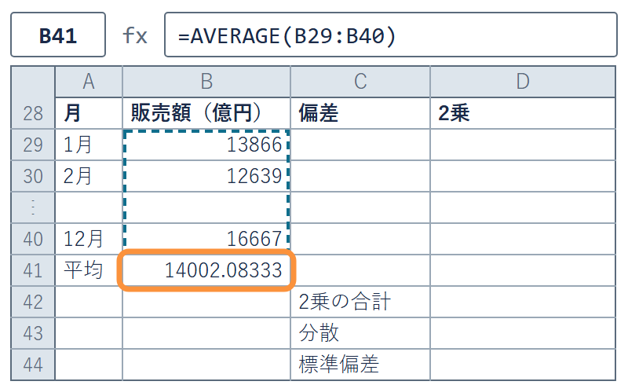

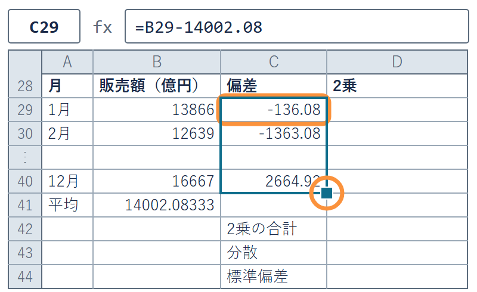

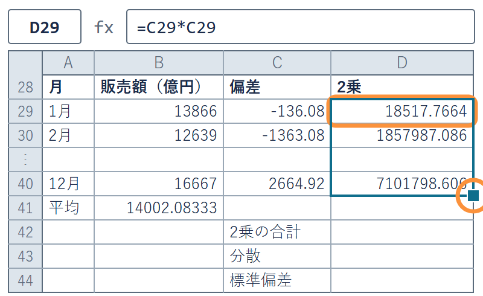

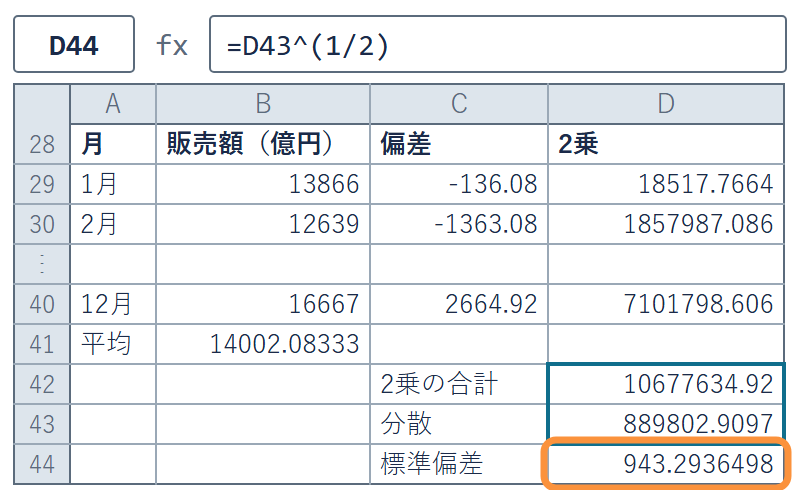

分散 ≒ 889,802.91（億円の 2 乗）。ルートで 943.29 億円に戻る

✋ 動画を止めて進め、D44 が 943.29 で始まる数なら再生に戻る

## 演習 3-2 1 人の点の跳ね上がり

演習 3-2

80 点の人が 100 点に上がったら  
クラス X の標準偏差はいくつか

1. **変える場所**：F16 の 80 を 100 にする
2. **予想**：7.07 の何倍か（ほぼ同じ／約 2 倍／約 3 倍）
3. **考える**：G17 が 0 でなくなる。新しい平均を出し、偏差の式の 70 をどう直すか
4. **答えを打つ**：G20 を小数 2 桁で K13 に打つ
5. **戻す**：F16 を 80 に戻す。B17 も `=B16-70` にして右へ

✋ 動画を止めて 4 分。K13 に打って元に戻したら再生に戻る

## 演習 3-2 の答え

演習 3-2 の答え

K13 は 13.93（7.07 の約 2 倍）

- **合計**：350 → 370（80 が 100 になり、20 増える）
- **平均**：70 → 74（370 ÷ 5）。偏差の式は `=B16-74` に直す
- **偏差**：−14・−9・−4・1・26（G17 は 0 に戻る）
- **2 乗の合計**：250 → 970（26 の 2 乗の 676 が大きい）
- **分散と標準偏差**：50 → 194 で、7.07 → 13.93

14.49 になった人は、偏差の式の 70 を直していない

## まとめ

- **偏差**：値 − 平均。足すと 0 になる
- **分散**：偏差の 2 乗の合計 ÷ 人数
- **標準偏差**：平均から、ふつうどれだけ離れているか
- **2 クラス**：平均は同じ 70 点、標準偏差は 7.07 と 21.21
- **販売額**：平均 14,002.08 億円、標準偏差は約 943 億円

次は、値を箱に分けて、散らばりの形を見る

経済データ入門

第3回 — Topic03

度数分布とヒストグラム

箱に分けて、形を見る

## この回の道のり

1

平均と中央値

演習 3-1

106 万円とカード

2

散らばり

演習 3-2

80 点を 100 点に

3

ヒストグラム

演習 3-3

29 で止める

4

形と代表値

演習 3-4

3 文で語る

いまここ — 箱に分けて、形を見る

## 「代表値と散らばり」シートで作る所

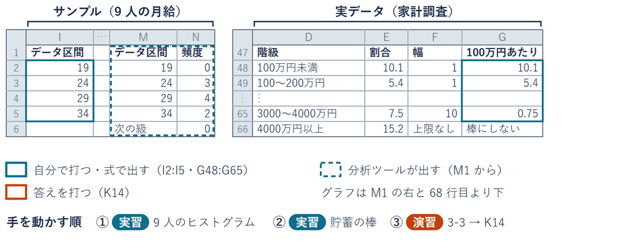

置き場は演習ブック lec3-exercise.xlsx の  
同じシートの I 列・M1 から右・46〜66 行目

## 9 人の月給の固まり方

9 人の月給は、どのあたりに固まっているか。5 万円ごとの箱で数える

| 社員 | A | B | C | D | E | F | G | H | I |
| --- | --- | --- | --- | --- | --- | --- | --- | --- | --- |
| 月給（万円） | 20 | 22 | 24 | 25 | 25 | 26 | 28 | 30 | 34 |

- **サンプルデータ**：トピック 1 で平均と中央値を出した 9 人
- **置き場**：lec3-exercise.xlsx の「代表値と散らばり」シートの 2〜10 行目
- **箱**：20 万円未満・20〜24・25〜29・30〜34（万円）の 4 つ

## 5 万円の箱への仕分け

[figure not shown]

箱ごとの人数は 0・3・4・2  
棒の高さで、人の固まる所が見える

## 階級・度数・ヒストグラムの定義

定義

**階級**＝値を分ける箱（区間）

**度数**＝その箱に入った人数

**ヒストグラム**＝度数を棒の高さにした図

- **今回の階級**：5 万円ずつの 4 つの箱
- **今回の度数**：0・3・4・2（足すと 9 人）
- **度数分布表**：階級と度数を並べた表

ヒストグラムを見ると、データがどこに固まるかという形が分かる

## データ区間の決まり

決まり

**データ区間**＝箱の上限を並べた列  
箱には、前の上限より大きく、この上限以下の値が入る  
最後の上限より大きい値は「次の級」に入る

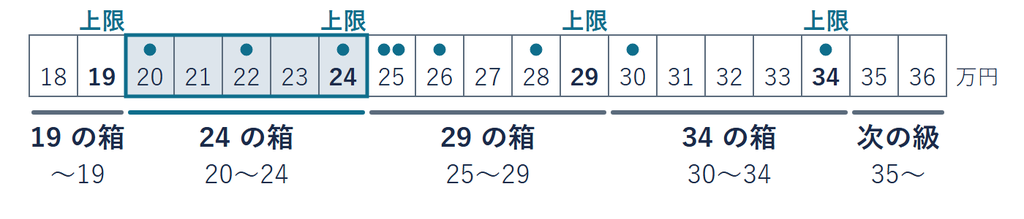

月給は整数なので、24 の箱＝20 以上 25 未満

## 失敗例 上限を 25 と書く誤り

よくある書き違い

「20 以上 25 未満」のつもりで  
データ区間に 25 と書く  
「未満」の 25 を  
そのまま上限だと思いやすい

正しくは

25 と書くと「25 以下」の箱  
25 万円の 2 人（D・E）も入り  
3 人から 5 人になる  
整数なら上限は 24 と書く

上限には、その箱に入れたい最大の値を書く

## データ区間と分析ツール

1. **打つ**：I2 に 19・I3 に 24  
   I1 の見出しは入っている
2. **伸ばす**：I2:I3 を選び I5 まで  
   オートフィル（19・24・29・34）
3. **開く**：「データ」→「データ分析」  
   →「ヒストグラム」→ OK

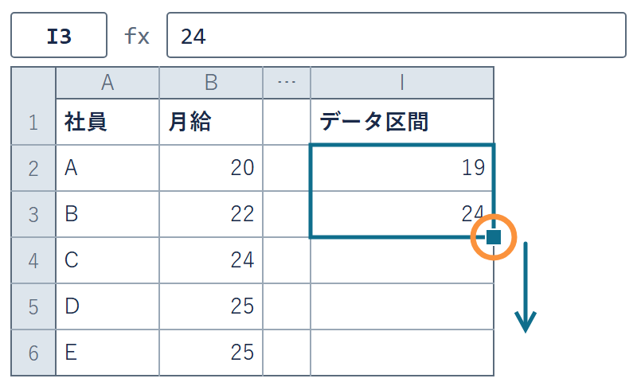

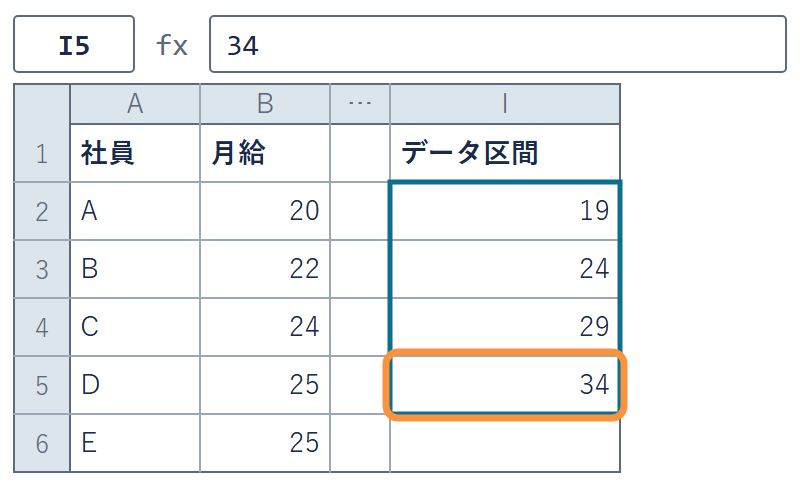

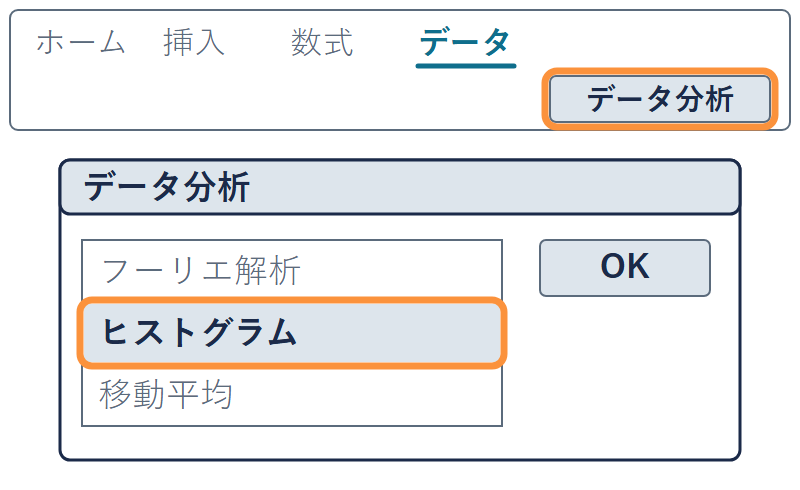

「データ分析」が無い人は、ガイダンス資料の手順で有効にする

✋ 動画を止めて STEP 1〜3 を進め、ダイアログが開いたら再生に戻る

## ヒストグラムのダイアログ

1. **範囲**：入力範囲に B1:B10  
   データ区間に I1:I5
2. **印**：「ラベル」に印  
   どちらも 1 行目が見出しのため
3. **出力**：出力先 M1  
   「グラフ作成」に印・OK

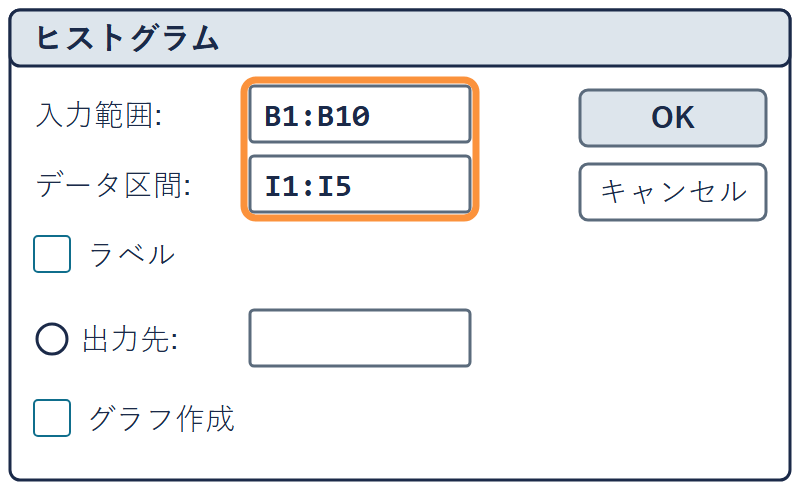

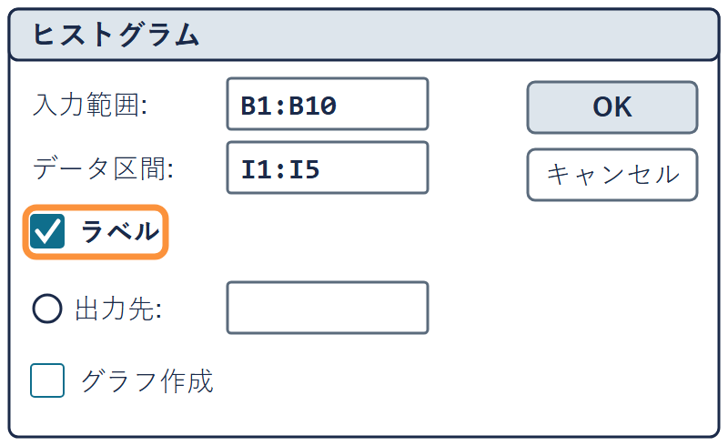

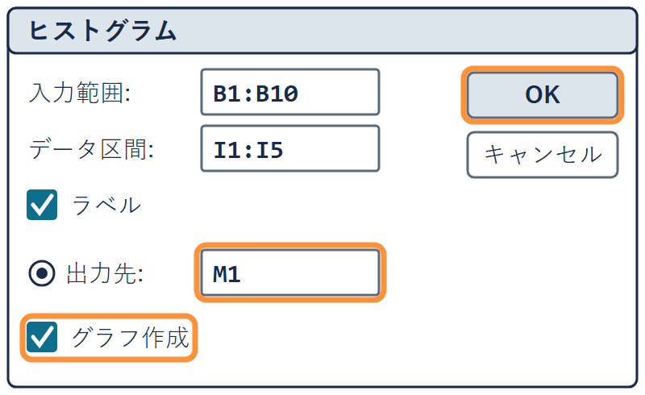

入力範囲は 9 人の B1:B10。12・13 行目の平均と中央値は入れない

✋ 動画を止めて STEP 1〜3 を進め、N2:N6 に頻度が出たら再生に戻る

## 出力の頻度と次の級

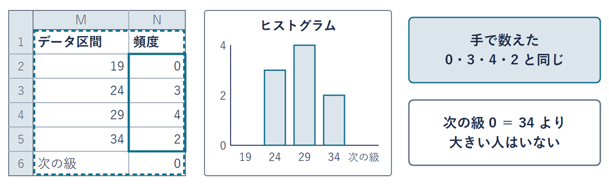

- **頻度**：N2:N6 に 0・3・4・2・0（手で数えた度数と同じ）
- **次の級**：34 より大きい値の人数。0 ならデータ区間は足りている
- **確かめ方**：頻度の合計は 9。9 人が全員どこかの箱に入った

## 家計の貯蓄の階級別の分布

今度は、家計の貯蓄を、公表された箱で見る

出典：総務省統計局「家計調査（貯蓄・負債編）2025年平均」第8-30表  
配布 PDF の 4 ページ目の図Ⅰ-1-3 と同じ値。置き場は D46:G66

| 2025 年・二人以上の世帯 | 世帯の割合（%） | 箱の幅 |
| --- | --- | --- |
| 100 万円未満 | 10.1 | 100 万円 |
| 100〜200 万円 | 5.4 | 100 万円 |
| ⋮ | ⋮ | ⋮ |
| 4000 万円以上 | 15.2 | 上限なし |

- **度数分布表**：公表された時点で、もう箱に分けてある
- **100 万円未満**：貯蓄 0 の世帯もこの箱に入る

## 割合のままの棒と 100 万円あたりの棒

[figure not shown]

- **サンプルデータ**：架空の 3 つの箱。A・B は幅 100 万円、C は幅 200 万円

割合のままだと、幅の広い C が高く見える。幅で割ると 8・6・5

## 幅のちがう箱のそろえ方

そろえ方

**100 万円あたりの割合**  
＝ 世帯の割合 ÷ 箱の幅（100 万円の何個分）

- **今回は**：1000〜1200 万円は 5.8 ÷ 2 ＝ 2.9
- **今回は**：3000〜4000 万円は 7.5 ÷ 10 ＝ 0.75
- **4000 万円以上**：幅が決まらないので、棒にしない（15.2%）
- **配布 PDF の図Ⅰ-1-3**：縦軸は同じ 100 万円あたり

## 貯蓄のヒストグラム

[figure not shown]

9 人と同じ順に読む。いちばん高い箱、次に右の低い棒